# FINAL_PROJECT

## Athena Topakas - Final Project

## Introduction:

## Scientific Question:

Does the specific protein hemagglutinin (HA) in the sequence of influenza A cause a more severe reaction compared to influenza B?

## Background of Protein:

The protein that I have chosen to test for this project is Hemagglutinin also known as (HA). This protein is found in the virus Influenza, and specifically in the viruses that I have chosen to further research for this project which are; Influenza A H1N1, Influenza A, H3N2, Influenza B, Yamagata, and Influenza B, Victoria. The protein Hemagglutinin plays an important role in the early stages of the virus. The HA protein is responsible for the virus's binding to cell surface receptors and for the viral genome's liberation into the cytoplasm via membrane fusion.

Source: https://pubmed.ncbi.nlm.nih.gov/9360372/

## Scientific Hypothesis:

The protein hemagglutinin is known to be found in all four strains of Influenza A and B and is also known to cause many mutations throughout the evolving sequences, especially Influenza A. Based on this previous research of the protein hemagglutinin in the infleunza strains, if humans have less immunity to Influenza A than they do to influenza B, then there may be structural differences in the HA protein for Influenza A and influenza B.

## Description of what analyses were done and how the data was downloaded for the project:

For DataBase#1 I used the DataBase National Center for Biotechnology (NCBI) to find my four different sequences. The four sequences I chose were: "Influenza A virus (A/Aichi/11/2006(H1N1)) HA1 gene for hemagglutinin, partial cds", "Influenza A virus (A/Beijing/114/2001(H3N2)) segment 4 hemagglutinin (HA) gene, partial cds", "Influenza B virus (B/Yamagata/45/2008) segment 4 hemagglutinin (HA) gene, partial cds", and "Influenza B virus (B/Victoria/201/2007) segment 4 hemagglutinin (HA) gene, partial cds". I combined all of my four sequences into one FASTA file to be able to do my code. The method#1 that I chose was Multiple Sequence Alignment. Multiple Sequence Alignment is a technique for detecting similarities between three or more biological sequences that could imply functional, structural, and/or evolutionary links such as protein or nucleic acid.

Source: https://www.ebi.ac.uk/Tools/msa/

For DataBase#2 I used the DataBase Protein Data Bank (PDB), and the four different structures I chose for each Influenza Sequence were: Influenza A, H1N1 (5WKO), Influenza A, H3N2 (3ZTJ), Influenza B, Yamagata (7KQI) and Influenza B, Victoria (4WE9). The method#2 that I chose was Homology Modeling and Structural Bioinformatics. Structural Bioinformatics is known to be the most accurate computer method for creating dependable structural models. While homology modeling uses template protein sequence alignment to estimate the 3D structure of a query protein.

Source: https://www.sciencedirect.com/topics/biochemistry-genetics-and-molecular-biology/homology-modeling#:~:text=Homology%20modeling%20is%20the%20most,sequence%20alignment%20of%20template%20proteins

The analyses that were done were Phylogenetic Clustering and 3-D Measurements. Phylogenetic cluster is a collection of sequences from the same or from different organisms that share a recent common ancestor. I incoorperated this into my project by uploading my fasta file of all four sequences into my Jupyter notebook from the DataBase National Center for Biotechnology. This analyses helped me determine and calculate the identity distance between each sequence and how different they each are from each other. 3-D Measurements are used to measure specific distances of each sequence to see how similar and related they are to each other. For my project, I went onto the DataBase Protein Data Bank and chose my four different strains and uploaded a fasta file for each structure on my Jupyter notebook. I was able to measure the distance between the alpha carbons for each structure that I chose using 3-D measurements.

Source: https://bmcbioinformatics.biomedcentral.com/articles/10.1186/1471-2105-14-317

## Defining Packages Loaded:

import nglview: This package that I loaded was for my method structural bioinformatics. It is also known as a python package which is able to "communicate" with underlying JavaScript library. This can only work if you put the proper files in the correct location where the code will be able to understand and remember where to get it from. For my project, I uploaded my files into the BIMM 143 file and was able to use nglview to call it from there. nglview is able to pass the URL of the file I am calling and Javascript then enables the structure to show from where I downloaded it.

Source: https://projects.volkamerlab.org/teachopencadd/talktorials/T017_advanced_nglview_usage.html#NGL-and-NGLView

import Bio: This package that I loaded was for my method Phylogenetic Clustering. It is also known as Biopython, this package is used in python and helps provide functions to deal with speicfic sequences such as DNA, RNA, and protein sequence operations. This package has the ability to read major genetic databases such as FASTA, NCBI and PDB that I used in this project. Some pro features for this package is that is is easy and clear to learn the syntax for it and it supports many software and tools.

Source: https://www.tutorialspoint.com/biopython/biopython_introduction.htm

## Global and Local Variable Definitions

Global Varibales: Global variables are not defined inside a function.

Local Variables: Local variables are defined inside a function.

## Multiple Sequence Alignment

As mentioned above, Multiple Sequence Alignment is a technique for detecting similarities between three or more biological sequences that could imply functional, structural, and/or evolutionary links such as protein or nucleic acid. The four sequences used for this alignment are taken from the NCBI database and made into a combined FASTA file. The sequences are; Influenza A virus (A/Aichi/11/2006(H1N1)) HA1 gene for hemagglutinin, partial cds", "Influenza A virus (A/Beijing/114/2001(H3N2)) segment 4 hemagglutinin (HA) gene, partial cds", "Influenza B virus (B/Yamagata/45/2008) segment 4 hemagglutinin (HA) gene, partial cds", and "Influenza B virus (B/Victoria/201/2007) segment 4 hemagglutinin (HA) gene, partial cds".

```python
#import sys lets us access system-specific parameters and functions
import sys
#this provides a simple uniform interface to input & output assorted sequence file formats (such as multiple sequence alignment)
from Bio import SeqIO
#this is for multiple sequence alignment program (operating systems)
from Bio.Align.Applications import MafftCommandline
#this creates a temp file in the temp directory and returns a file object
import tempfile
```

```python
#variable fasta is for all my 4 sequence data (Global Variable)
fasta = "sequence (4).fasta"
```

```python
# Global Variable
reference = 0
count = 0
```

```python
conda install -c bioconda mafft
```

```
Solving environment: done

# All requested packages already installed.
```

```python
#recieves a file that has a name (uses it to create a temp file)
with tempfile.NamedTemporaryFile() as temp:
    #for loop using if else
    for record in SeqIO.parse("sequence (4).fasta", "fasta"):
        #(Local variables)
        if count == 0:
            reference = record
        else:
            #(Local variables)
            SeqIO.write([reference, record], temp.name, "fasta")
            mafft_cline = MafftCommandline(input=temp.name)
            stdout,stderr=mafft_cline()
            print(stdout)
        count += 1
        print('\n')
```

```
>KP461123.1 Influenza B virus (B/Yamagata/45/2008) segment 4 hemagglutinin (HA) gene, partial cds
gatcgaatctgcactggaataacatcttcaaactcacctcatgtggtcaaaacagccact
caaggggaggtcaatgtgactggtgtgataccactaacaacaacaccaacaaaatcttat
tttgcaaatctcaaaggaacaaggaccagagggaaactatgcccagactgtctcaactgc
acagatctggatgtggctttgggcagaccaatgtgtgtggggaccacaccttcggcgaaa
gcttcaatactccacgaagtcagacctgttacatccgggtgctttcctataatgcacgac
agaacaaaaatcaggcaactacccaatcttctcagaggatatgaaaatatcaggctatca
acccaaaacgtcatcgatgcggaaaaggcaccaggaggaccctacagacttggaacctca
ggatcttgccctaacgctaccagtaagagcggatttttcgcaacaatggcttgggctgtc
ccaaaggacaacaacaaaaatgcaacgaacccactaacagtagaagtaccatacatttgt
acagaaggggaagaccaaatcactgtttgggggttccattcagataacaaaacccaaatg
aagaacctctatggagactcaaatcctcaaaagttcacctcatctgctaatggagtaacc
acacactatgtttctcagattggcagcttcccagatcaaacagaagacggaggactacca
caaagcggcaggattgttgttgattacatgatgcaaaaacctgggaaaacaggaacaatt
gtctaccaaagaggtgttttgttgcctcaaagggtgtggtgcgcgagtggcaggagcaaa
gtaataaaagggtccttgcctttaattggtgaagcagattgccttcatgaaaaatacggt
ggattaaacaaaagcaagccttactacacaggagaacatgcaaaagccataggaaattgc
ccaatatgggtgaaaaca
>KP461405.1 Influenza B virus (B/Victoria/201/2007) segment 4 hemagglutinin (HA) gene, partial cds
gatcgaatctgcactgggataacatcgtcaaactcacctcatgtggtcaaaacagctact
caaggggaggtcaatgtgactggtgtgataccactgacaacaacaccaacaaaatcttat
tttgcaaatctcaaaggaacaaagaccagagggaaactatgcccagactgtctcaactgt
acagatctggatgtggccttgggcaggccaatgtgtgtgggaaccacaccttctgcgaaa
gcttcaatactccacgaagtcagacctgttacatccgggtgctttcctataatgcacgac
agaacaaaaatcaggcaactagccaatcttctcagaggatatgaaaatatcaggttatca
acccaaaacgttatcgatgcagaaaaggcaccgggaggaccctacagacttggaacctca
ggatcttgccctaacgctaccagtaaaagcggatttttcgcaacaatggcttgggctgtc
ccaaaggacaacaacaaaaatgcaacgaacccactaacagtagaagtaccatacatttgt
acagaaggggaagaccaaattactgtttgggggttccattcagataacaaaacccaaatg
aagaacctctatggagactcaaatcctcaaaagttcacctcatctgctaatggagtaacc
acacattatgtttctcagattggcggcttcccagatcaaacagaagacggaggactacca
caaagcggcagaattgtcgttgattacatgatgcaaaaacctgggaaaacaggaacaatt
gtctatcaaagaggtgttttgttgcctcaaaaggtgtggtgcgcgagtggcaggagcaaa
gtaataaaagggtccttgcctttaattggtgaagcagattgccttcatgaaaaatacggt
ggattaaacaaaagcaagccttactacacaggagaacatgcaaaagccataggaaattgc
ccaatatgggtgaaaaca



>KP461123.1 Influenza B virus (B/Yamagata/45/2008) segment 4 hemagglutinin (HA) gene, partial cds
```

[output cut: 67 more lines]

```
gaatgcgaattactgatttccaaggaatca--------------tggtcctacattgtag
aaacaccaaatcctgagaatggaacatgttacccagggtatttcgccgactatgaggaac
tgagggagcaattgagttcagtatcttcatttgagaggttcgaaatattccccaaagaga
gctcatggcccaaccacaccgtaaccggagtatcagcatcatgctccca---taacggga
aaagcagtttttacagaaatttgctatggctgacggggaagaatggtctgtacccaaacc
tgagcaagtcctatgcaaacaacaaagagaaagaagtccttgtactatggggtgttcatc
accctcctaacataggg---gaccaaa----------gggccctctatcatacagaaaat
gctta------tgtctctgtagtgtcttcacattatagcagaagattcacccca------
---gaaatagccaaa----------------------------------agacccaaggt
gagagat-----caggaaggaagaatcaactactactggactctgctggaacccggggat
acaataatatttgaggcaaatggaaatctaatagcgccaaggtttgctttcgcactgagt
agaggctttggat------------------caggaatcatcacctcgaatgcaccaatg
gatgaatgtgatgcgaagtgtcaaacacctcaaggagctataaacagcagtcttcctttc
cagaatgtacacccagtcacaataggagagtgtccaaagtatgtcaggagtgcaaaatta
aggatggctacaggactaaggaacatcccatccattcaatccagg
```

Note: The results here show that Infleunza A, H3N2 differs the most out of all four sequences.

## Structural bioinformatics

As mentioned above, structural bioinformatics is known to be the most accurate computer method for creating dependable structural models. The four structures below are taken from the PDB database, and the ascention codes that are used are influenza A H1N1: "5WKO", influenza A H3N2: "3ZTJ", influenza B Yamagata: "7KQI", and influenza B Victoria: "4WE9". Importing nglview enables us to see the structure of the HA protein found in each strain and sequence.

```python
#importing nglview to be able to view the structure of each sequence
import nglview as nv
```

```python
#showing structure of influenza A H1N1
view = nv.show_pdbid("5WKO")
view
```

```python
#showing structure of influenza A H3N2
view = nv.show_pdbid("3ZTJ")
view
```

```python
#showing structure of influenza B Yamagata
view = nv.show_pdbid("7KQI")
view
```

```python
# showing structure of Influenza B Victoria
view = nv.show_pdbid("4WE9")
view
```

Source: http://life.nthu.edu.tw/~fmhsu/rasframe/COLORS.HTM

## Phylogenetic Clustering

As mentioned above, Phylogenetic cluster is a collection of sequences from the same or from different organisms that share a recent common ancestor. I incoorperated this into my project by uploading my fasta file of all four sequences into my Jupyter notebook from the DataBase National Center for Biotechnology. This analyses helped me determine and calculate the identity distance between each sequence and how different they each are from each other.

```python
#import Bio
import Bio
#import Phylo, AlignIO from Bio
from Bio import Phylo, AlignIO
#import DistanceCalculator, DistanceTreeConstructor from Bio.Phylo.TreeConstruction
from Bio.Phylo.TreeConstruction import DistanceCalculator, DistanceTreeConstructor
```

[output not shown]

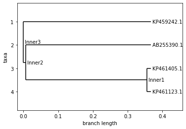

```python
#Read and align query sequences (Global variable)
My_alignment = AlignIO.read("sequence (4).fasta", "fasta")

#Print the alignment from the fasta sequence above
print(My_alignment)

#Calculate the distance matrix (Global variables)
Calculate = DistanceCalculator('identity')
Distance_Matrix = calculator.get_distance(My_alignment)

#Print the distance matrix result
print(Distance_Matrix)

#Creating a DistanceTreeConstructor object (Global Variables)
Distance_Tree_Constructor = DistanceTreeConstructor()

#Constructing the phylogenetic tree (Global variables)
Tree = Distance_Tree_Constructor.upgma(distMatrix)

#This draws and shows the phylogenetic tree
Phylo.draw(Tree)
```

Note: Infleunza A H1N1: AB255390.1 Influneza A H3N2: KP459242.1 Influenza B Yamagata: KP461123.1 Infleunza B Victoria: KP461405.1

The phylogentic tree above shows that Influenza B Yamagata: KP461123.1 and Infleunza B Victoria: KP461405.1 are very similar to each other and the next most similar strain is Infleunza A H1N1: AB255390.1 and the farthest one is Influneza A H3N2: KP459242.1.

## 3D Measurements

As mentioned above, 3-D Measurements are used to measure specific distances of each sequence to see how similar and related they are to each other. For my project, I went onto the DataBase Protein Data Bank and chose my four different strains and uploaded a fasta file for each structure on my Jupyter notebook. I was able to measure the distance between the alpha carbons for each structure that I chose using 3-D measurements.

Note: The structures that I chose are: Infleunza A H1N1: 5WKO, Influneza A H3N2: 3ZTJ, Influenza B Yamagata: 7KQI, Infleunza B Victoria: 4WE9

```python
#import PDBParser from Bio.PDB.PDBParser
from Bio.PDB.PDBParser import PDBParser
```

```python
#Influenza A H3N2 (Global variable)
parser = PDBParser()
#Get protein structure of H3N2 (Global variable)
structure_of_H3N2 = parser.get_structure("3ZTJ", "3ztj.pdb")
#Get the residues from the protein structure of H3N2 (Global variable)
residues_H3N2 = [r for r in structure_of_H3N2.get_residues()]
#Calculate the distance between alpha carbons (Global variable)
ca1_H3N2 = residues_H3N2[0]["CA"]
ca2_H3N2 = residues_H3N2[1]["CA"]
distance_H3N2 = ca1_H3N2 - ca2_H3N2
#Print
print(distance_H3N2)
```

```
3.9006157
```

```python
#Influenza A H1N1 (Global variable)
parser = PDBParser()
#Get protein structure of H1N1 (Global variable)
structure_of_H1N1 = parser.get_structure("5WKO", "5wko.pdb")
#Get the residues from the protein structure of H1N1 (Global variable)
residues_H1N1 = [r for r in structure_of_H1N1.get_residues()]
#Calculate the distance between alpha carbons (Global variable)
ca1_H1N1 = residues_H1N1[0]["CA"]
ca2_H1N1 = residues_H1N1[1]["CA"]
distance_H1N1 = ca1_H1N1 - ca2_H1N1
#Print
print(distance_H1N1)
```

```
3.82491
```

```python
#Influenza B Yamagata (Global variable)
parser = PDBParser()
#Get protein structure of B Yamagata (Global variable)
structure_of_B_Yamagata = parser.get_structure("7KQI", "7kqi.pdb")
#Get the residues from the protein structure of B Yamagata (Global variable)
residues_B_Yamagata = [r for r in structure_of_B_Yamagata.get_residues()]
#Calculate the distance between alpha carbons (Global variable)
ca1_B_Yamagata = residues_B_Yamagata[0]["CA"]
ca2_B_Yamagata = residues_B_Yamagata[1]["CA"]
distance_B_Yamagata = ca1_B_Yamagata - ca2_B_Yamagata
#Print
print(distance_B_Yamagata)
```

```
3.8054087
```

```python
#Influenza B Victoria (Global variable)
parser = PDBParser()
#Get protein structure of B Victoria (Global variable)
structure_of_B_Victoria = parser.get_structure("4WE9", "4we9.pdb")
#Get the residues from the protein structure of B Victoria (Global variable)
residues_B_Victoria = [r for r in structure_of_B_Victoria.get_residues()]
#Calculate the distance between alpha carbons (Global variable)
ca1_B_Victoria = residues_B_Victoria[0]["CA"]
ca2_B_Victoria = residues_B_Victoria[1]["CA"]
distance_B_Victoria = ca1_B_Victoria - ca2_B_Victoria
#Print
print(distance_B_Victoria)
```

```
3.8022718
```

Note: I was able to measure the distance between the alpha carbons for each structure that I chose using 3-D measurements. These results are similar to the phylogenetic clustering results which show that Influenza A H1N1, Infleunza B Yamagata, and Influenza B Victoria are the similar to each other while Infleunza A H3N2 is the farthest distance between all three.